####*Objective 4. Filter out genes with low expression and plot*

Packages used in this notebook: `edgeR`, `RColorBrewer`. First verify that they are installed and loaded.

The next step is to filter out genes with low intensity (this is a crude way of filtering - it’s not a recommendation, just showing how this could be done). In this case, we will select rows (genes) where at least 3 of the 9 samples have counts/million >1.

```r
dge_sub <- dge[rowSums(cpm>1)>=3, ]
```

If this code seems mysterious, break it down!

```r
head(cpm)
```

```
           Samples
Tags        GSM1545535_10_6_5_11 GSM1545536_9_6_5_11 GSM1545538_purep53 GSM1545539_JMS8-2 GSM1545540_JMS8-3
  497097              0.03042931          0.05660032         5.98311952        10.2397134        0.03958043
  100503874           0.00000000          0.00000000         0.08747251         0.1168028        0.00000000
  100038431           0.00000000          0.00000000         0.00000000         0.0000000        0.00000000
  19888               0.00000000          0.02830016         0.00000000         0.0000000        0.22428910
  20671               0.03042931          0.02830016         1.32958212         0.7786854        0.43538472
  27395              13.11503265         21.81942229        23.93247808        24.6843282       20.63459725
           Samples
Tags        GSM1545541_JMS8-4 GSM1545542_JMS8-5 GSM1545544_JMS9-P7c GSM1545545_JMS9-P8c
  497097           0.04957231        9.71202943          0.09384795           0.0000000
  100503874        0.00000000        0.09076663          0.00000000           0.0000000
  100038431        0.00000000        0.01815333          0.00000000           0.0000000
  19888            0.03304821        0.00000000          0.04692397           0.0000000
  20671            0.23133744        1.77902595          0.84463153           0.4008249
  27395           12.70703524       14.84942070         21.96041982          17.1352661
```

```r
head(rowSums(cpm>1))
```

```
   497097 100503874 100038431     19888     20671     27395
        3         0         0         0         2         9
```

```r
head(rowSums(cpm>1)>=3)
```

```
   497097 100503874 100038431     19888     20671     27395
     TRUE     FALSE     FALSE     FALSE     FALSE      TRUE
```

**Discussion:** What are some ways to decide on the filtering criteria? How do you do it? What are the strengths and weaknesses of these options:

- Intensity-based (e.g. decide a-priori: if genes are not expressed in x% of samples, remove).
- Statistically-based (e.g. calculate coefficient of variation CV or adjusted p-values for each gene across samples, decide a-priori to remove genes outside of a certain range).
- Biologically-based (e.g. look at genes of interest).

Now compare the size of the original raw count data to the filtered data.

```r
dim(dge)
```

```
[1] 27179     9
```

```r
dim(dge_sub)
```

```
[1] 14165     9
```

```r
nrow(dge_sub) / nrow(dge)
```

```
[1] 0.5211744
```

Let’s plot the raw and filtered data distributions (density) side-by-side. First let’s assign different colors to each of the 9 samples so we can overlay them.

```r
?RColorBrewer

nsamples <- ncol(dge_sub)
col <- brewer.pal(nsamples, "Paired")
col
```

```
[1] "#A6CEE3" "#1F78B4" "#B2DF8A" "#33A02C" "#FB9A99" "#E31A1C" "#FDBF6F" "#FF7F00" "#CAB2D6"
```

Here we want to use the log2(CPM) values for both raw and filtered data. We created `log2_cpm` in Objective 3 but we’ll create it here again and name it `log2cpm_raw` to distingush it from the filtered data `log2cpm_sub`.

```r
log2cpm_raw <- cpm(dge, log=TRUE)
log2cpm_sub <- cpm(dge_sub, log=TRUE)
```

The `density()` function from the `stats` package will give us the data to plot the raw and filtered data. Notice the different ranges for the log2(CPM) values (x).

```r
density(log2cpm_raw[,1])
```

```
Call:
    density.default(x = log2cpm_raw[, 1])

Data: log2cpm_raw[, 1] (27179 obs.);    Bandwidth 'bw' = 0.5129

       x                 y
 Min.   :-6.0460   Min.   :3.300e-07
 1st Qu.:-0.4591   1st Qu.:1.878e-03
 Median : 5.1279   Median :4.078e-02
 Mean   : 5.1279   Mean   :4.469e-02
 3rd Qu.:10.7148   3rd Qu.:6.215e-02
 Max.   :16.3018   Max.   :2.592e-01
```

```r
density(log2cpm_sub[,1])
```

```
Call:
    density.default(x = log2cpm_sub[, 1])

Data: log2cpm_sub[, 1] (14165 obs.);    Bandwidth 'bw' = 0.3697

       x                 y
 Min.   :-5.6164   Min.   :8.600e-07
 1st Qu.:-0.2443   1st Qu.:2.395e-03
 Median : 5.1279   Median :2.026e-02
 Mean   : 5.1279   Mean   :4.649e-02
 3rd Qu.:10.5000   3rd Qu.:8.668e-02
 Max.   :15.8722   Max.   :1.508e-01
```

We will set up a plot with 1 row, 2 columns (2 plots) so we can make side-by-side density plots. We’ll put the raw data on the left plot and the filtered data on the right. This is done with the `par()` function (see `?par` for general plot parameters).

We’ll start by making the first plot of just the first sample, then we will combine the samples using a for loop and overlay these as lines on the same plot.

```r
par(mfrow=c(1,2))
plot(density(log2cpm_raw[,1]),
     col=col[1],
     lwd=2,
     ylim=c(0,0.21),
     las=2,
     main="",
     xlab="")
title(main="A. Raw data", xlab="Log2(CPM)")
```

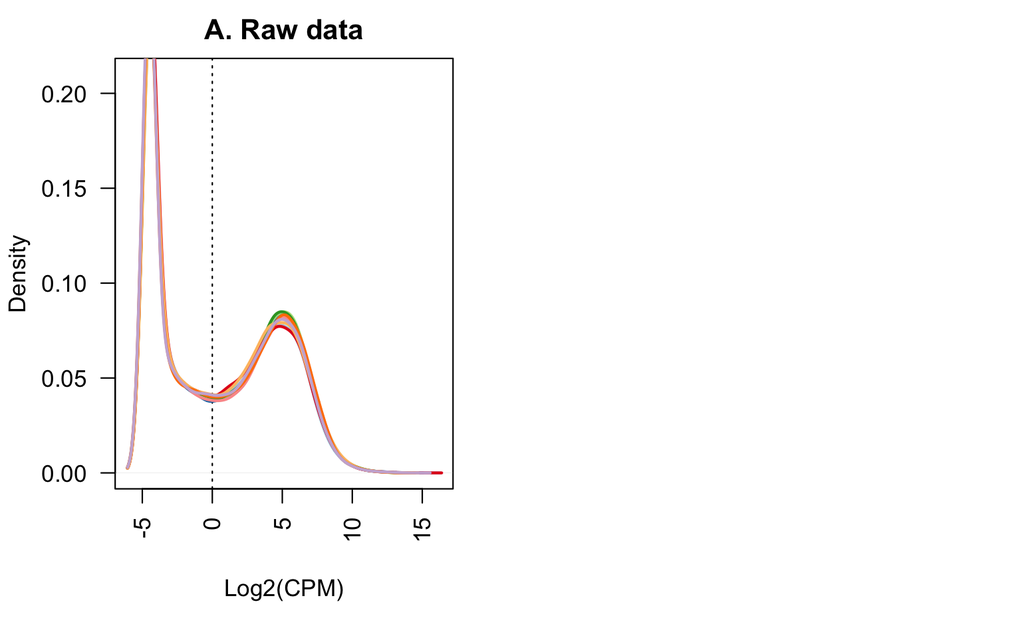

```r
abline(v=0, lty=3)

for (i in 2:nsamples){
    den <- density(log2cpm_raw[,i])
    lines(den$x, den$y, col=col[i], lwd=2)
}
```

Next we can make the second plot of filtered data on the right like we did for the raw data.  
We’ll put all of the code together for the final plot.

```r
par(mfrow=c(1,2))
plot(density(log2cpm_raw[,1]),
     col=col[1],
     lwd=2,
     ylim=c(0,0.21),
     las=2,
     main="",
     xlab="")
title(main="A. Raw data", xlab="Log2(CPM)")
```

```r
abline(v=0, lty=3)

for (i in 2:nsamples){
    den <- density(log2cpm_raw[,i])
    lines(den$x, den$y, col=col[i], lwd=2)
}
```

```r
plot(density(log2cpm_sub[,1]),
    col=col[1],
    lwd=2,
    ylim=c(0,0.21),
    las=2,
    main="",
    xlab="")
title(main="B. Filtered data", xlab="Log2(CPM)")
```

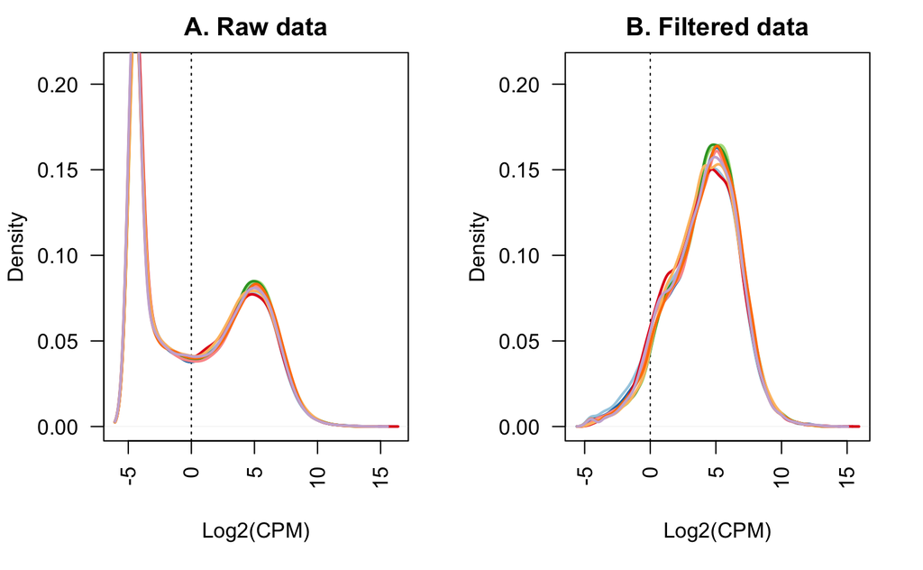

```r
abline(v=0, lty=3)

for (i in 2:nsamples){
    den <- density(log2cpm_sub[,i])
    lines(den$x, den$y, col=col[i], lwd=2)
}
```

**Question:** why is there that peak on the left side of the raw data? Recall the `cpm` function:

```r
?cpm
```